# Visit with Us — Wellness Tourism Package: End-to-End MLOps Pipeline

**MLOps Capstone Project**

## Business Context

*Visit with Us*, a leading travel company, is introducing a new **Wellness Tourism Package**. Currently, identifying which customers to target is manual, inconsistent, and error-prone, which leads to missed opportunities and poor campaign performance.

The goal of this project is to build a **scalable, automated MLOps pipeline** that predicts whether a customer will purchase the Wellness Tourism Package **before** the sales team contacts them — enabling efficient targeting, timely model updates, and data-driven marketing decisions.

## Objective

Design and deploy an MLOps pipeline that automates the full workflow: data registration → preparation → model building (with experiment tracking) → deployment → CI/CD with GitHub Actions. The trained model is registered on the Hugging Face Model Hub and served through a Streamlit front-end hosted on Hugging Face Spaces.

## Pipeline Overview

| Stage | Tool / Script | Output |
| --- | --- | --- |
| Data Registration | `data_register.py` | Raw data on HF **dataset** space |
| Data Preparation | `prep.py` | Clean `train.csv` / `test.csv` on HF |
| Model Building | `train.py` | Tuned XGBoost, tracked with MLflow, registered on HF **model** hub |
| Deployment | `app.py`, `Dockerfile`, `hosting.py` | Streamlit app on HF **Space** |
| CI/CD | `.github/workflows/pipeline.yml` | Automated end-to-end run on every push to `main` |

## Submission Links

- **GitHub repository:** `https://github.com/prudvikrishna/tourism-mlops`
- **Hugging Face dataset:** `https://huggingface.co/datasets/prudvikrishna/tourism`
- **Hugging Face model:** `https://huggingface.co/prudvikrishna/tourism-package-model`
- **Hugging Face Space (Streamlit app):** `https://huggingface.co/spaces/prudvikrishna/tourism-package-predictor`

## 0. Environment Setup

```python
import os
import warnings
import numpy as np
import pandas as pd
import matplotlib.pyplot as plt
import seaborn as sns

from sklearn.model_selection import train_test_split, GridSearchCV
from sklearn.compose import ColumnTransformer
from sklearn.pipeline import Pipeline
from sklearn.preprocessing import StandardScaler, OneHotEncoder
from sklearn.metrics import (accuracy_score, precision_score, recall_score,
                             f1_score, roc_auc_score, classification_report,
                             confusion_matrix, RocCurveDisplay)
from xgboost import XGBClassifier

warnings.filterwarnings("ignore")
sns.set_style("whitegrid")
pd.set_option("display.max_columns", None)

RANDOM_STATE = 42
TARGET = "ProdTaken"
print("Libraries imported successfully.")
```

```
Libraries imported successfully.
```

## 1. Data Registration

We create a master project folder with a `data` subfolder and register the raw dataset on a Hugging Face **dataset** space. This gives every downstream stage a single, versioned source of truth.

**Folder structure**

```
tourism-mlops/
└── tourism_project/
    └── data/
        ├── tourism.csv          <- raw data
        └── data_register.py     <- registration script
```

The registration script (`tourism_project/data/data_register.py`) is shown below. It is executed in CI (and can be run locally) once `HF_USERNAME` and `HF_TOKEN` are set.

```python
data_register_code = r"""
import os
from huggingface_hub import HfApi, create_repo

HF_USERNAME = os.getenv("HF_USERNAME", "HF_USERNAME")
DATASET_REPO_ID = f"{HF_USERNAME}/tourism"

def main():
    token = os.getenv("HF_TOKEN")
    api = HfApi(token=token)
    create_repo(DATASET_REPO_ID, repo_type="dataset", token=token,
                private=False, exist_ok=True)
    api.upload_file(path_or_fileobj="tourism.csv", path_in_repo="tourism.csv",
                    repo_id=DATASET_REPO_ID, repo_type="dataset")
    print("Raw data registered on HF dataset space:", DATASET_REPO_ID)
"""
print(data_register_code)
```

```
import os
from huggingface_hub import HfApi, create_repo

HF_USERNAME = os.getenv("HF_USERNAME", "HF_USERNAME")
DATASET_REPO_ID = f"{HF_USERNAME}/tourism"

def main():
    token = os.getenv("HF_TOKEN")
    api = HfApi(token=token)
    create_repo(DATASET_REPO_ID, repo_type="dataset", token=token,
                private=False, exist_ok=True)
    api.upload_file(path_or_fileobj="tourism.csv", path_in_repo="tourism.csv",
                    repo_id=DATASET_REPO_ID, repo_type="dataset")
    print("Raw data registered on HF dataset space:", DATASET_REPO_ID)
```

```python
# Execute registration only if a write token is configured (skipped during local notebook runs)
if os.getenv("HF_TOKEN"):
    from huggingface_hub import HfApi, create_repo
    HF_USERNAME = os.getenv("HF_USERNAME", "HF_USERNAME")
    DATASET_REPO_ID = f"{HF_USERNAME}/tourism"
    api = HfApi(token=os.getenv("HF_TOKEN"))
    create_repo(DATASET_REPO_ID, repo_type="dataset", token=os.getenv("HF_TOKEN"),
                private=False, exist_ok=True)
    api.upload_file(path_or_fileobj="tourism_project/data/tourism.csv",
                    path_in_repo="tourism.csv", repo_id=DATASET_REPO_ID, repo_type="dataset")
    print("Raw data registered on HF dataset space:", DATASET_REPO_ID)
else:
    print("HF_TOKEN not set -> skipping live upload. (Runs automatically in GitHub Actions.)")
```

```
HF_TOKEN not set -> skipping live upload. (Runs automatically in GitHub Actions.)
```

## 2. Data Preparation

We load the dataset (from the HF dataset space in production; from the local copy here so outputs are reproducible), explore it, clean it, split it into train/test, and upload the splits back to HF.

```python
# In production this loads from the HF dataset space:
#   from huggingface_hub import hf_hub_download
#   path = hf_hub_download(DATASET_REPO_ID, "tourism.csv", repo_type="dataset")
# For a reproducible notebook run we read the local registered copy:
df = pd.read_csv("tourism_project/data/tourism.csv", index_col=0)
print("Shape:", df.shape)
df.head()
```

```
Shape: (4128, 20)
```

|  | CustomerID | ProdTaken | Age | TypeofContact | CityTier | DurationOfPitch | Occupation | Gender | NumberOfPersonVisiting | NumberOfFollowups | ProductPitched | PreferredPropertyStar | MaritalStatus | NumberOfTrips | Passport | PitchSatisfactionScore | OwnCar | NumberOfChildrenVisiting | Designation | MonthlyIncome |
| --- | --- | --- | --- | --- | --- | --- | --- | --- | --- | --- | --- | --- | --- | --- | --- | --- | --- | --- | --- | --- |
| 0 | 200000 | 1 | 41.0 | Self Enquiry | 3 | 6.0 | Salaried | Female | 3 | 3.0 | Deluxe | 3.0 | Single | 1.0 | 1 | 2 | 1 | 0.0 | Manager | 20993.0 |
| 1 | 200001 | 0 | 49.0 | Company Invited | 1 | 14.0 | Salaried | Male | 3 | 4.0 | Deluxe | 4.0 | Divorced | 2.0 | 0 | 3 | 1 | 2.0 | Manager | 20130.0 |
| 2 | 200002 | 1 | 37.0 | Self Enquiry | 1 | 8.0 | Free Lancer | Male | 3 | 4.0 | Basic | 3.0 | Single | 7.0 | 1 | 3 | 0 | 0.0 | Executive | 17090.0 |
| 3 | 200003 | 0 | 33.0 | Company Invited | 1 | 9.0 | Salaried | Female | 2 | 3.0 | Basic | 3.0 | Divorced | 2.0 | 1 | 5 | 1 | 1.0 | Executive | 17909.0 |
| 5 | 200005 | 0 | 32.0 | Company Invited | 1 | 8.0 | Salaried | Male | 3 | 3.0 | Basic | 3.0 | Single | 1.0 | 0 | 5 | 1 | 1.0 | Executive | 18068.0 |

### 2.1 Exploratory Data Analysis

```python
df.info()
```

```
<class 'pandas.core.frame.DataFrame'>
Index: 4128 entries, 0 to 4887
Data columns (total 20 columns):
 #   Column                    Non-Null Count  Dtype
---  ------                    --------------  -----
 0   CustomerID                4128 non-null   int64
 1   ProdTaken                 4128 non-null   int64
 2   Age                       4128 non-null   float64
 3   TypeofContact             4128 non-null   object
 4   CityTier                  4128 non-null   int64
 5   DurationOfPitch           4128 non-null   float64
 6   Occupation                4128 non-null   object
 7   Gender                    4128 non-null   object
 8   NumberOfPersonVisiting    4128 non-null   int64
 9   NumberOfFollowups         4128 non-null   float64
 10  ProductPitched            4128 non-null   object
 11  PreferredPropertyStar     4128 non-null   float64
 12  MaritalStatus             4128 non-null   object
 13  NumberOfTrips             4128 non-null   float64
 14  Passport                  4128 non-null   int64
 15  PitchSatisfactionScore    4128 non-null   int64
 16  OwnCar                    4128 non-null   int64
 17  NumberOfChildrenVisiting  4128 non-null   float64
 18  Designation               4128 non-null   object
 19  MonthlyIncome             4128 non-null   float64
dtypes: float64(7), int64(7), object(6)
memory usage: 677.2+ KB
```

```python
df.describe(include="all").T
```

|  | count | unique | top | freq | mean | std | min | 25% | 50% | 75% | max |
| --- | --- | --- | --- | --- | --- | --- | --- | --- | --- | --- | --- |
| CustomerID | 4128.0 | NaN | NaN | NaN | 202527.763808 | 1409.439133 | 200000.0 | 201320.75 | 202603.5 | 203748.25 | 204887.0 |
| ProdTaken | 4128.0 | NaN | NaN | NaN | 0.193072 | 0.394757 | 0.0 | 0.0 | 0.0 | 0.0 | 1.0 |
| Age | 4128.0 | NaN | NaN | NaN | 37.231831 | 9.174521 | 18.0 | 31.0 | 36.0 | 43.0 | 61.0 |
| TypeofContact | 4128 | 2 | Self Enquiry | 2918 | NaN | NaN | NaN | NaN | NaN | NaN | NaN |
| CityTier | 4128.0 | NaN | NaN | NaN | 1.663275 | 0.92064 | 1.0 | 1.0 | 1.0 | 3.0 | 3.0 |
| DurationOfPitch | 4128.0 | NaN | NaN | NaN | 15.584787 | 8.398142 | 5.0 | 9.0 | 14.0 | 20.0 | 127.0 |
| Occupation | 4128 | 4 | Salaried | 1999 | NaN | NaN | NaN | NaN | NaN | NaN | NaN |
| Gender | 4128 | 3 | Male | 2463 | NaN | NaN | NaN | NaN | NaN | NaN | NaN |
| NumberOfPersonVisiting | 4128.0 | NaN | NaN | NaN | 2.94937 | 0.718818 | 1.0 | 2.0 | 3.0 | 3.0 | 5.0 |
| NumberOfFollowups | 4128.0 | NaN | NaN | NaN | 3.741521 | 1.006786 | 1.0 | 3.0 | 4.0 | 4.0 | 6.0 |
| ProductPitched | 4128 | 5 | Basic | 1615 | NaN | NaN | NaN | NaN | NaN | NaN | NaN |
| PreferredPropertyStar | 4128.0 | NaN | NaN | NaN | 3.578488 | 0.795031 | 3.0 | 3.0 | 3.0 | 4.0 | 5.0 |
| MaritalStatus | 4128 | 4 | Married | 1990 | NaN | NaN | NaN | NaN | NaN | NaN | NaN |
| NumberOfTrips | 4128.0 | NaN | NaN | NaN | 3.2953 | 1.8563 | 1.0 | 2.0 | 3.0 | 4.0 | 22.0 |
| Passport | 4128.0 | NaN | NaN | NaN | 0.2953 | 0.456233 | 0.0 | 0.0 | 0.0 | 1.0 | 1.0 |
| PitchSatisfactionScore | 4128.0 | NaN | NaN | NaN | 3.060804 | 1.363064 | 1.0 | 2.0 | 3.0 | 4.0 | 5.0 |
| OwnCar | 4128.0 | NaN | NaN | NaN | 0.612161 | 0.487317 | 0.0 | 0.0 | 1.0 | 1.0 | 1.0 |
| NumberOfChildrenVisiting | 4128.0 | NaN | NaN | NaN | 1.223595 | 0.852685 | 0.0 | 1.0 | 1.0 | 2.0 | 3.0 |
| Designation | 4128 | 5 | Executive | 1615 | NaN | NaN | NaN | NaN | NaN | NaN | NaN |
| MonthlyIncome | 4128.0 | NaN | NaN | NaN | 23178.464147 | 4506.614622 | 1000.0 | 20751.0 | 22418.0 | 25301.0 | 98678.0 |

```python
# Missing values per column
missing = df.isnull().sum()
print(missing[missing > 0] if missing.sum() else "No missing values.")
```

```
No missing values.
```

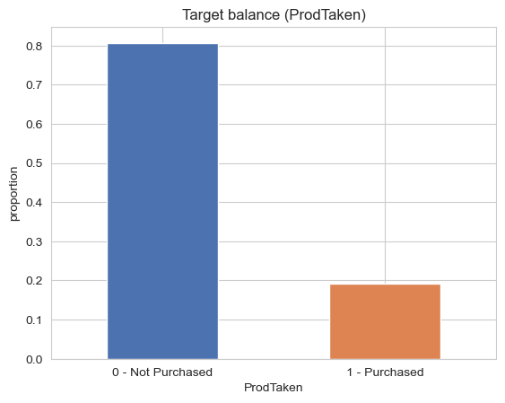

```
{0: 0.807, 1: 0.193}
```

```python
# Target balance
ax = df[TARGET].value_counts(normalize=True).plot(kind="bar", color=["#4C72B0", "#DD8452"])
ax.set_title("Target balance (ProdTaken)")
ax.set_xticklabels(["0 - Not Purchased", "1 - Purchased"], rotation=0)
ax.set_ylabel("proportion")
plt.show()
print(df[TARGET].value_counts(normalize=True).round(3).to_dict())
```

```python
# Inspect categorical columns for inconsistencies
for c in df.select_dtypes(include="object").columns:
    print(f"--- {c} ---")
    print(df[c].value_counts(), "\n")
```

```
--- TypeofContact ---
TypeofContact
Self Enquiry       2918
Company Invited    1210
Name: count, dtype: int64

--- Occupation ---
Occupation
Salaried          1999
Small Business    1746
Large Business     381
Free Lancer          2
Name: count, dtype: int64

--- Gender ---
Gender
Male       2463
Female     1510
Fe Male     155
Name: count, dtype: int64

--- ProductPitched ---
ProductPitched
Basic           1615
Deluxe          1422
Standard         737
Super Deluxe     250
King             104
Name: count, dtype: int64

--- MaritalStatus ---
MaritalStatus
Married      1990
Divorced      789
Unmarried     682
Single        667
Name: count, dtype: int64

--- Designation ---
Designation
Executive         1615
Manager           1422
Senior Manager     737
AVP                250
VP                 104
Name: count, dtype: int64
```

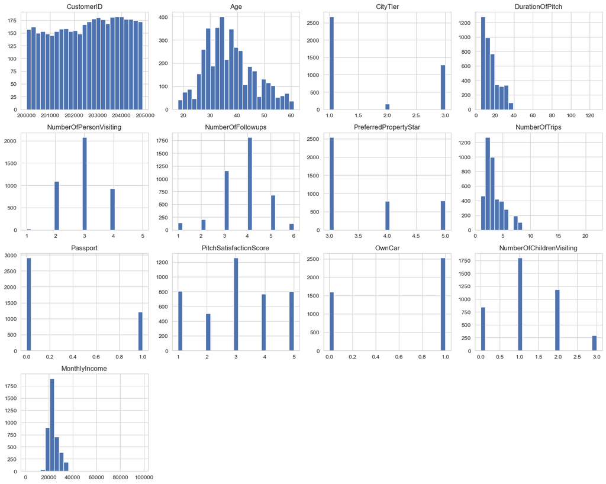

```python
# Numeric distributions
num_cols_eda = df.select_dtypes(include="number").drop(columns=[TARGET]).columns
df[num_cols_eda].hist(figsize=(15, 12), bins=25, color="#4C72B0")
plt.tight_layout(); plt.show()
```

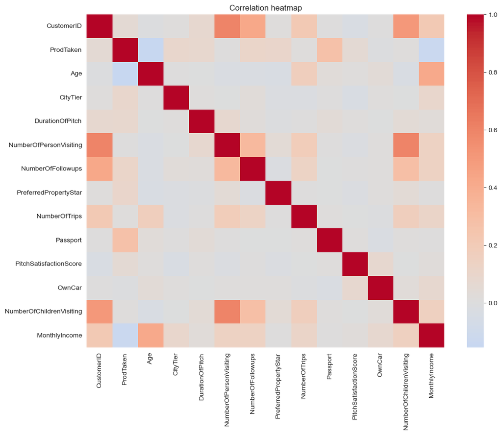

```python
# Correlation heatmap (numeric features)
plt.figure(figsize=(12, 9))
sns.heatmap(df.select_dtypes(include="number").corr(), annot=False, cmap="coolwarm", center=0)
plt.title("Correlation heatmap"); plt.show()
```

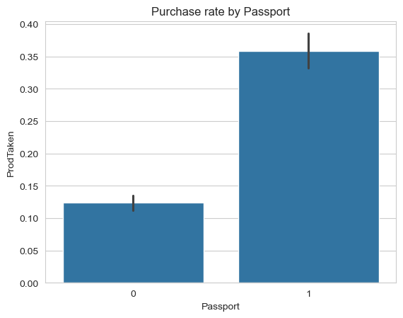

```python
# Purchase rate by Passport (a known strong driver)
sns.barplot(data=df, x="Passport", y=TARGET); plt.title("Purchase rate by Passport"); plt.show()
```

**EDA observations**

- The target is **imbalanced** (~81% no-purchase vs ~19% purchase). We address this with `scale_pos_weight` in XGBoost and use **F1 / ROC-AUC** rather than accuracy.
- `Gender` contains a typo category **"Fe Male"** which must be merged into **"Female"**.
- `MaritalStatus` has both **"Unmarried"** and **"Single"** — semantically the same, so we merge them.
- `CustomerID` is a unique identifier with no predictive value → dropped.
- Customers **holding a passport** purchase the package at a noticeably higher rate.

### 2.2 Data Cleaning

```python
def clean(df):
    df = df.loc[:, ~df.columns.str.contains("^Unnamed")]
    if "CustomerID" in df.columns:
        df = df.drop(columns=["CustomerID"])
    df["Gender"] = df["Gender"].replace({"Fe Male": "Female"})
    df["MaritalStatus"] = df["MaritalStatus"].replace({"Unmarried": "Single"})
    for col in df.columns:
        if df[col].isnull().any():
            if df[col].dtype == "object":
                df[col] = df[col].fillna(df[col].mode()[0])
            else:
                df[col] = df[col].fillna(df[col].median())
    return df

df_clean = clean(df)
print("Cleaned shape:", df_clean.shape)
print("Gender:", df_clean['Gender'].unique())
print("MaritalStatus:", df_clean['MaritalStatus'].unique())
df_clean.head()
```

```
Cleaned shape: (4128, 19)
Gender: ['Female' 'Male']
MaritalStatus: ['Single' 'Divorced' 'Married']
```

|  | ProdTaken | Age | TypeofContact | CityTier | DurationOfPitch | Occupation | Gender | NumberOfPersonVisiting | NumberOfFollowups | ProductPitched | PreferredPropertyStar | MaritalStatus | NumberOfTrips | Passport | PitchSatisfactionScore | OwnCar | NumberOfChildrenVisiting | Designation | MonthlyIncome |
| --- | --- | --- | --- | --- | --- | --- | --- | --- | --- | --- | --- | --- | --- | --- | --- | --- | --- | --- | --- |
| 0 | 1 | 41.0 | Self Enquiry | 3 | 6.0 | Salaried | Female | 3 | 3.0 | Deluxe | 3.0 | Single | 1.0 | 1 | 2 | 1 | 0.0 | Manager | 20993.0 |
| 1 | 0 | 49.0 | Company Invited | 1 | 14.0 | Salaried | Male | 3 | 4.0 | Deluxe | 4.0 | Divorced | 2.0 | 0 | 3 | 1 | 2.0 | Manager | 20130.0 |
| 2 | 1 | 37.0 | Self Enquiry | 1 | 8.0 | Free Lancer | Male | 3 | 4.0 | Basic | 3.0 | Single | 7.0 | 1 | 3 | 0 | 0.0 | Executive | 17090.0 |
| 3 | 0 | 33.0 | Company Invited | 1 | 9.0 | Salaried | Female | 2 | 3.0 | Basic | 3.0 | Divorced | 2.0 | 1 | 5 | 1 | 1.0 | Executive | 17909.0 |
| 5 | 0 | 32.0 | Company Invited | 1 | 8.0 | Salaried | Male | 3 | 3.0 | Basic | 3.0 | Single | 1.0 | 0 | 5 | 1 | 1.0 | Executive | 18068.0 |

### 2.3 Train / Test Split and Save

```python
train_df, test_df = train_test_split(
    df_clean, test_size=0.20, random_state=RANDOM_STATE, stratify=df_clean[TARGET])

train_df.to_csv("tourism_project/data/train.csv", index=False)
test_df.to_csv("tourism_project/data/test.csv", index=False)
print("train:", train_df.shape, "| test:", test_df.shape)
print("train target balance:", train_df[TARGET].mean().round(3),
      "| test target balance:", test_df[TARGET].mean().round(3))
```

```
train: (3302, 19) | test: (826, 19)
train target balance: 0.193 | test target balance: 0.192
```

```python
# Upload splits back to HF dataset space (runs in CI; guarded locally)
if os.getenv("HF_TOKEN"):
    for fn in ["train.csv", "test.csv"]:
        api.upload_file(path_or_fileobj=f"tourism_project/data/{fn}", path_in_repo=fn,
                        repo_id=DATASET_REPO_ID, repo_type="dataset")
        print("Uploaded", fn)
else:
    print("HF_TOKEN not set -> splits saved locally only.")
```

```
HF_TOKEN not set -> splits saved locally only.
```

## 3. Model Building with Experiment Tracking

We build a preprocessing + **XGBoost** pipeline, tune it with **GridSearchCV**, log all parameters and metrics (MLflow in production), evaluate on the held-out test set, and register the best model on the Hugging Face Model Hub.

```python
X_train, y_train = train_df.drop(columns=[TARGET]), train_df[TARGET]
X_test, y_test = test_df.drop(columns=[TARGET]), test_df[TARGET]

num_cols = X_train.select_dtypes(include="number").columns.tolist()
cat_cols = X_train.select_dtypes(include="object").columns.tolist()
print("Numeric:", num_cols)
print("Categorical:", cat_cols)

preprocessor = ColumnTransformer([
    ("num", StandardScaler(), num_cols),
    ("cat", OneHotEncoder(handle_unknown="ignore"), cat_cols),
])

pipe = Pipeline([
    ("preprocessor", preprocessor),
    ("model", XGBClassifier(objective="binary:logistic", eval_metric="logloss",
                            random_state=RANDOM_STATE, scale_pos_weight=4)),
])
```

```
Numeric: ['Age', 'CityTier', 'DurationOfPitch', 'NumberOfPersonVisiting', 'NumberOfFollowups', 'PreferredPropertyStar', 'NumberOfTrips', 'Passport', 'PitchSatisfactionScore', 'OwnCar', 'NumberOfChildrenVisiting', 'MonthlyIncome']
Categorical: ['TypeofContact', 'Occupation', 'Gender', 'ProductPitched', 'MaritalStatus', 'Designation']
```

### 3.1 Define parameters and tune

```python
param_grid = {
    "model__n_estimators": [100, 200],
    "model__max_depth": [3, 5, 7],
    "model__learning_rate": [0.05, 0.1],
    "model__subsample": [0.8, 1.0],
}

grid = GridSearchCV(pipe, param_grid=param_grid, scoring="f1", cv=3, n_jobs=-1, verbose=1)
grid.fit(X_train, y_train)
best_model = grid.best_estimator_
print("Best CV F1:", round(grid.best_score_, 4))
```

```
Fitting 3 folds for each of 24 candidates, totalling 72 fits
Best CV F1: 0.7871
```

### 3.2 Log all tuned parameters

```python
print("Best parameters (logged to MLflow in production):")
for k, v in grid.best_params_.items():
    print(f"  {k} = {v}")

# In production these are logged with MLflow:
#   import mlflow
#   mlflow.set_experiment("tourism-wellness-package")
#   with mlflow.start_run():
#       mlflow.log_params(grid.best_params_)
#       mlflow.log_metrics(metrics)
```

```
Best parameters (logged to MLflow in production):
  model__learning_rate = 0.1
  model__max_depth = 7
  model__n_estimators = 200
  model__subsample = 1.0
```

### 3.3 Evaluate model performance

```python
y_pred = best_model.predict(X_test)
y_proba = best_model.predict_proba(X_test)[:, 1]

metrics = {
    "accuracy": accuracy_score(y_test, y_pred),
    "precision": precision_score(y_test, y_pred),
    "recall": recall_score(y_test, y_pred),
    "f1": f1_score(y_test, y_pred),
    "roc_auc": roc_auc_score(y_test, y_proba),
}
pd.Series(metrics).round(4)
```

```
accuracy     0.9419
precision    0.8627
recall       0.8302
f1           0.8462
roc_auc      0.9779
dtype: float64
```

```python
print(classification_report(y_test, y_pred))
```

```
              precision    recall  f1-score   support

           0       0.96      0.97      0.96       667
           1       0.86      0.83      0.85       159

    accuracy                           0.94       826
   macro avg       0.91      0.90      0.91       826
weighted avg       0.94      0.94      0.94       826
```

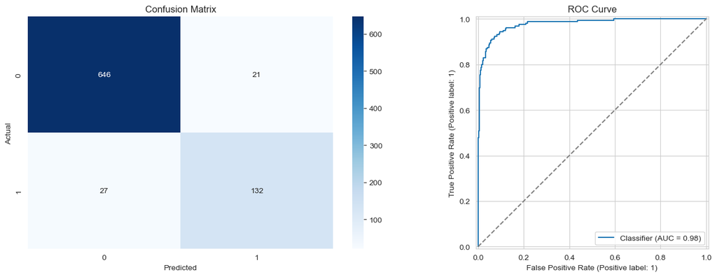

```python
fig, ax = plt.subplots(1, 2, figsize=(14, 5))
sns.heatmap(confusion_matrix(y_test, y_pred), annot=True, fmt="d", cmap="Blues", ax=ax[0])
ax[0].set_title("Confusion Matrix"); ax[0].set_xlabel("Predicted"); ax[0].set_ylabel("Actual")
RocCurveDisplay.from_predictions(y_test, y_proba, ax=ax[1])
ax[1].set_title("ROC Curve"); ax[1].plot([0, 1], [0, 1], "--", color="grey")
plt.tight_layout(); plt.show()
```

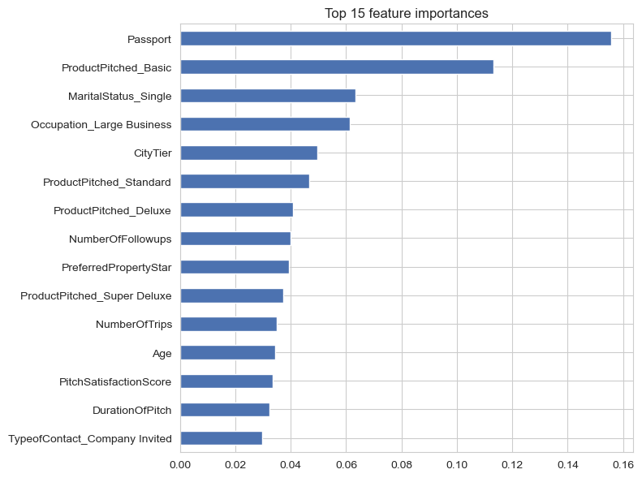

```python
# Feature importance (top 15)
ohe = best_model.named_steps["preprocessor"].named_transformers_["cat"]
feat_names = num_cols + list(ohe.get_feature_names_out(cat_cols))
importances = best_model.named_steps["model"].feature_importances_
fi = pd.Series(importances, index=feat_names).sort_values(ascending=False).head(15)
fi.sort_values().plot(kind="barh", figsize=(8, 6), color="#4C72B0")
plt.title("Top 15 feature importances"); plt.tight_layout(); plt.show()
```

### 3.4 Register the best model on the Hugging Face Model Hub

```python
import joblib
joblib.dump(best_model, "best_tourism_model.joblib")
print("Model saved locally.")

if os.getenv("HF_TOKEN"):
    HF_USERNAME = os.getenv("HF_USERNAME", "HF_USERNAME")
    MODEL_REPO_ID = f"{HF_USERNAME}/tourism-package-model"
    create_repo(MODEL_REPO_ID, repo_type="model", token=os.getenv("HF_TOKEN"),
                private=False, exist_ok=True)
    api.upload_file(path_or_fileobj="best_tourism_model.joblib",
                    path_in_repo="best_tourism_model.joblib",
                    repo_id=MODEL_REPO_ID, repo_type="model")
    print("Best model registered on HF model hub:", MODEL_REPO_ID)
else:
    print("HF_TOKEN not set -> model registration runs in GitHub Actions.")
```

```
Model saved locally.
HF_TOKEN not set -> model registration runs in GitHub Actions.
```

## 4. Model Deployment

The model is served through a **Streamlit** app packaged in a **Docker** image and hosted on a Hugging Face **Space**. The deployment artifacts live in `tourism_project/deployment/`:

- `Dockerfile` — defines the container (Python 3.10, port 7860, Streamlit entry point).
- `requirements.txt` — deployment dependencies.
- `app.py` — collects inputs, builds a single-row DataFrame in the training schema, loads the model from the HF model hub, and returns the purchase probability.
- `hosting.py` — creates the Space (Docker SDK) and pushes all deployment files into it.

```python
dockerfile = r"""
FROM python:3.10-slim
RUN useradd -m -u 1000 user
USER user
ENV HOME=/home/user PATH=/home/user/.local/bin:$PATH
WORKDIR $HOME/app
COPY --chown=user requirements.txt .
RUN pip install --no-cache-dir -r requirements.txt
COPY --chown=user . .
EXPOSE 7860
CMD ["streamlit", "run", "app.py", "--server.port=7860", "--server.address=0.0.0.0"]
"""
print(dockerfile)
```

```
FROM python:3.10-slim
RUN useradd -m -u 1000 user
USER user
ENV HOME=/home/user PATH=/home/user/.local/bin:$PATH
WORKDIR $HOME/app
COPY --chown=user requirements.txt .
RUN pip install --no-cache-dir -r requirements.txt
COPY --chown=user . .
EXPOSE 7860
CMD ["streamlit", "run", "app.py", "--server.port=7860", "--server.address=0.0.0.0"]
```

```python
hosting_code = r"""
import os
from huggingface_hub import HfApi, create_repo

HF_USERNAME = os.getenv("HF_USERNAME", "HF_USERNAME")
SPACE_REPO_ID = f"{HF_USERNAME}/tourism-package-predictor"
api = HfApi(token=os.getenv("HF_TOKEN"))
create_repo(SPACE_REPO_ID, repo_type="space", space_sdk="docker",
            token=os.getenv("HF_TOKEN"), private=False, exist_ok=True)
for f in ["app.py", "Dockerfile", "requirements.txt"]:
    api.upload_file(path_or_fileobj=f, path_in_repo=f,
                    repo_id=SPACE_REPO_ID, repo_type="space")
print("Deployment files pushed to HF Space:", SPACE_REPO_ID)
"""
print(hosting_code)
```

```
import os
from huggingface_hub import HfApi, create_repo

HF_USERNAME = os.getenv("HF_USERNAME", "HF_USERNAME")
SPACE_REPO_ID = f"{HF_USERNAME}/tourism-package-predictor"
api = HfApi(token=os.getenv("HF_TOKEN"))
create_repo(SPACE_REPO_ID, repo_type="space", space_sdk="docker",
            token=os.getenv("HF_TOKEN"), private=False, exist_ok=True)
for f in ["app.py", "Dockerfile", "requirements.txt"]:
    api.upload_file(path_or_fileobj=f, path_in_repo=f,
                    repo_id=SPACE_REPO_ID, repo_type="space")
print("Deployment files pushed to HF Space:", SPACE_REPO_ID)
```

## 5. MLOps Pipeline with GitHub Actions

A single workflow file, `.github/workflows/pipeline.yml`, automates the **end-to-end** pipeline. On every push to `main` (or manual dispatch) it runs four sequential jobs: `data-registration → data-preparation → model-training → deployment`.

The `HF_USERNAME` and `HF_TOKEN` are stored as **GitHub repository secrets**.

```python
pipeline_yml = r"""
name: Tourism MLOps Pipeline
on:
  push:
    branches: [main]
  workflow_dispatch:
env:
  HF_USERNAME: ${{ secrets.HF_USERNAME }}
  HF_TOKEN: ${{ secrets.HF_TOKEN }}
jobs:
  data-registration:
    runs-on: ubuntu-latest
    steps:
      - uses: actions/checkout@v4
      - uses: actions/setup-python@v5
        with: {python-version: '3.10'}
      - run: pip install -r requirements.txt
      - run: python tourism_project/data/data_register.py
  data-preparation:
    needs: data-registration
    runs-on: ubuntu-latest
    steps:
      - uses: actions/checkout@v4
      - uses: actions/setup-python@v5
        with: {python-version: '3.10'}
      - run: pip install -r requirements.txt
      - run: python tourism_project/data/prep.py
  model-training:
    needs: data-preparation
    runs-on: ubuntu-latest
    steps:
      - uses: actions/checkout@v4
      - uses: actions/setup-python@v5
        with: {python-version: '3.10'}
      - run: pip install -r requirements.txt
      - run: python tourism_project/model_building/train.py
  deployment:
    needs: model-training
    runs-on: ubuntu-latest
    steps:
      - uses: actions/checkout@v4
      - uses: actions/setup-python@v5
        with: {python-version: '3.10'}
      - run: pip install -r requirements.txt
      - run: python tourism_project/deployment/hosting.py
"""
print(pipeline_yml)
```

```
name: Tourism MLOps Pipeline
on:
  push:
    branches: [main]
  workflow_dispatch:
env:
  HF_USERNAME: ${{ secrets.HF_USERNAME }}
  HF_TOKEN: ${{ secrets.HF_TOKEN }}
jobs:
  data-registration:
    runs-on: ubuntu-latest
    steps:
      - uses: actions/checkout@v4
      - uses: actions/setup-python@v5
        with: {python-version: '3.10'}
      - run: pip install -r requirements.txt
      - run: python tourism_project/data/data_register.py
  data-preparation:
    needs: data-registration
    runs-on: ubuntu-latest
    steps:
      - uses: actions/checkout@v4
      - uses: actions/setup-python@v5
        with: {python-version: '3.10'}
      - run: pip install -r requirements.txt
      - run: python tourism_project/data/prep.py
  model-training:
    needs: data-preparation
    runs-on: ubuntu-latest
    steps:
      - uses: actions/checkout@v4
      - uses: actions/setup-python@v5
        with: {python-version: '3.10'}
      - run: pip install -r requirements.txt
      - run: python tourism_project/model_building/train.py
  deployment:
    needs: model-training
    runs-on: ubuntu-latest
    steps:
      - uses: actions/checkout@v4
      - uses: actions/setup-python@v5
        with: {python-version: '3.10'}
      - run: pip install -r requirements.txt
      - run: python tourism_project/deployment/hosting.py
```

## 7. Insights & Conclusion

**MLOps insights**

- Centralising data on the HF dataset space removes the "works on my machine" problem — every stage pulls the same versioned data.
- Experiment tracking (MLflow) makes runs reproducible and comparable.
- GitHub Actions chains the whole lifecycle so a single push to `main` re-runs data prep, retraining, and redeployment — enabling continuous improvement as customer behaviour evolves.

**Business impact**

- The sales team can prioritise customers with a high predicted purchase probability, reducing wasted outreach and increasing conversion for the Wellness Tourism Package.

**Next steps**

- Add probability-threshold tuning aligned to campaign budget, SHAP explanations in the app, data-drift monitoring, and scheduled retraining triggers.